# Bank Marketing Prediction

### Domain

Banking

### Context:

Leveraging customer information is paramount for most businesses. In the case of a bank, attributes of customers like the ones mentioned below can be crucial in strategizing a marketing campaign when launching a new product.

### Objective:

The objective is to help the marketing team identify potential customers who are relatively more likely to subscribe to the bank term deposit. The classification goal is to predict if the client will subscribe (yes/no) a term deposit (variable y).

### Attribute Information:

**1. age** (numeric)  
**2. job** : type of job (categorical: 'admin.','blue-collar','entrepreneur','housemaid','management','retired','self-employed','services','student','technician','unemployed','unknown')  
**3. marital :** marital status (categorical: 'divorced','married','single','unknown'; note: 'divorced' means divorced or widowed)  
**4. education :**(categorical:'basic.4y','basic.6y','basic.9y','high.school','illiterate','professional.course','university.degree','unknown')  
**5. default:** has credit in default? (categorical: 'no','yes','unknown')  
**6. balance:** average yearly balance, in euros (numeric)  
**7. housing:** has housing loan? (categorical: 'no','yes','unknown')  
**8. loan:** has personal loan? (categorical: 'no','yes','unknown')  
**9. contact:** contact communication type (categorical: 'cellular','telephone')  
**10. day:** last contact day of the month (numeric 1 -31)  
**11. month:** last contact month of year (categorical: 'jan', 'feb', 'mar', ..., 'nov', 'dec')  
**12. duration:** last contact duration, in seconds (numeric).  
**Important note** : this attribute highly affects the output target (e.g., if duration=0 then y='no'). Yet, the duration is not known before a call is performed. Also, after the end of the call y is obviously known. Thus, this input should only be included for benchmark purposes and should be discarded if the intention is to have a realistic predictive model.  
**13. campaign:** number of contacts performed during this campaign and for this client (numeric, includes last contact)  
**14. pdays:** number of days that passed by after the client was last contacted from a previous campaign (numeric; 999 means client was not previously contacted)  
**15. previous:** number of contacts performed before this campaign and for this client (numeric)  
**16. poutcome:** outcome of the previous marketing campaign (categorical:'failure','nonexistent','success')  
**17. target:** has the client subscribed a term deposit? (binary: "yes","no")

### Categorical Attributes

1. Job
2. Martial
3. Education
4. default
5. housing
6. loan
7. contact
8. month
9. poutcome

### Numerical Attributes

1. Age
2. balance
3. day
4. duration
5. campaign
6. pdays
7. previous

### Target Attribute

Target

# Steps and tasks:

## 1. Import the necessary libraries

```python
import numpy as np
import pandas as pd
import matplotlib.pyplot as plt
%matplotlib inline
import seaborn as sns
import warnings
warnings.filterwarnings('ignore')
```

## 2. Read the data as a data frame

```python
# read the data

bankData = pd.read_csv("bank-full.csv")
```

```python
bankData.head()
```

|  | age | job | marital | education | default | balance | housing | loan | contact | day | month | duration | campaign | pdays | previous | poutcome | Target |
| --- | --- | --- | --- | --- | --- | --- | --- | --- | --- | --- | --- | --- | --- | --- | --- | --- | --- |
| 0 | 58 | management | married | tertiary | no | 2143 | yes | no | unknown | 5 | may | 261 | 1 | -1 | 0 | unknown | no |
| 1 | 44 | technician | single | secondary | no | 29 | yes | no | unknown | 5 | may | 151 | 1 | -1 | 0 | unknown | no |
| 2 | 33 | entrepreneur | married | secondary | no | 2 | yes | yes | unknown | 5 | may | 76 | 1 | -1 | 0 | unknown | no |
| 3 | 47 | blue-collar | married | unknown | no | 1506 | yes | no | unknown | 5 | may | 92 | 1 | -1 | 0 | unknown | no |
| 4 | 33 | unknown | single | unknown | no | 1 | no | no | unknown | 5 | may | 198 | 1 | -1 | 0 | unknown | no |

## 3. Perform basic EDA and put out your insights at every step.

### a. Shape of the data

```python
bankData.shape
```

```
(45211, 17)
```

**As we see there are 45211 rows and 17 attributes in the dataset.**

### b. Data type of each attribute

```python
bankData.info()
```

```
<class 'pandas.core.frame.DataFrame'>
RangeIndex: 45211 entries, 0 to 45210
Data columns (total 17 columns):
age          45211 non-null int64
job          45211 non-null object
marital      45211 non-null object
education    45211 non-null object
default      45211 non-null object
balance      45211 non-null int64
housing      45211 non-null object
loan         45211 non-null object
contact      45211 non-null object
day          45211 non-null int64
month        45211 non-null object
duration     45211 non-null int64
campaign     45211 non-null int64
pdays        45211 non-null int64
previous     45211 non-null int64
poutcome     45211 non-null object
Target       45211 non-null object
dtypes: int64(7), object(10)
memory usage: 5.9+ MB
```

**As it is already known, we have 7 numerical attributes, and 10 categorical attributes.**

### c. Checking the presence of missing values

```python
print("Missing values if any (True/False)? :", bankData.isnull().values.any())
bankData.isna().apply(pd.value_counts)
```

```
Missing values if any (True/False)? : False
```

|  | age | job | marital | education | default | balance | housing | loan | contact | day | month | duration | campaign | pdays | previous | poutcome | Target |
| --- | --- | --- | --- | --- | --- | --- | --- | --- | --- | --- | --- | --- | --- | --- | --- | --- | --- |
| False | 45211 | 45211 | 45211 | 45211 | 45211 | 45211 | 45211 | 45211 | 45211 | 45211 | 45211 | 45211 | 45211 | 45211 | 45211 | 45211 | 45211 |

**As we see from the above two results, there are no missing or null values in the dataset.**

### d. 5 Point summary of numerical attributes

```python
# we have 7 numerical coloumns
# so we use include=np.number on descibe to get the summary of only these 7 columns

# Note : We can also use : exclude=[np.object], to eliminate the non-numerical attributes

bankData.describe(include=[np.number]).T
```

|  | count | mean | std | min | 25% | 50% | 75% | max |
| --- | --- | --- | --- | --- | --- | --- | --- | --- |
| age | 45211.0 | 40.936210 | 10.618762 | 18.0 | 33.0 | 39.0 | 48.0 | 95.0 |
| balance | 45211.0 | 1362.272058 | 3044.765829 | -8019.0 | 72.0 | 448.0 | 1428.0 | 102127.0 |
| day | 45211.0 | 15.806419 | 8.322476 | 1.0 | 8.0 | 16.0 | 21.0 | 31.0 |
| duration | 45211.0 | 258.163080 | 257.527812 | 0.0 | 103.0 | 180.0 | 319.0 | 4918.0 |
| campaign | 45211.0 | 2.763841 | 3.098021 | 1.0 | 1.0 | 2.0 | 3.0 | 63.0 |
| pdays | 45211.0 | 40.197828 | 100.128746 | -1.0 | -1.0 | -1.0 | -1.0 | 871.0 |
| previous | 45211.0 | 0.580323 | 2.303441 | 0.0 | 0.0 | 0.0 | 0.0 | 275.0 |

**Age**

- Average age of the people in the dataset is ~41 with std of 10.61
- 75 percentage of the people have 48 or less age.

**Balance**

- Average balance of the people in the dataset is 1362.27 with std of 3044.76, as standard deviation is quite huge it means that balance is wide spread across the dataset.
- 75 percentage of the people have 1428 or less balance. So we expect to see some outliers.

**duration**

- Average duration of the people speaking in the dataset is 258.16 with std of 257
- 75 percentage of the people spoke for 319 seconds or less. So many outliers might exist.

**campaign**

- Average no. of contacts performed during the current campaign for a client in the dataset is 2.76 with std of 3.09.
- 75 percentage of the clients has been contacted 3 times or less in the current campaign.

**pdays**

- Average no.of days passed after the client was contacted from previous campaign in the dataset is 40.19 with std of 100.12.
- In comparison with 75% quantile, 871 is a distant outlier.

### e. Checking the presence of outliers

```python
# we define outliers by using Inter Quantile range.
# Data_point > (Q3 * 1.5) is said to be outlier where Q3 is 75% Quantile !

# selecting numeric columns in dataset
numerics = ['int16', 'int32', 'int64', 'float16', 'float32', 'float64']
num_df = bankData.select_dtypes(include=numerics)

# finding the IQR for each of the numerical columns
Q1 = num_df.quantile(0.25)
Q3 = num_df.quantile(0.75)
IQR = Q3 - Q1

# checking for outliers, True represents outlier
num_df_mod = ((num_df < (Q1 - 1.5 * IQR)) |(num_df > (Q3 + 1.5 * IQR)))

# iterating over columns to check for no.of outliers in each of the numerical attributes.
for col in num_df_mod:
    if(1 in num_df_mod[col].value_counts().index):
        print("No. of outliers in %s: %d" %( col, num_df_mod[col].value_counts().iloc[1]))
    else:
        print("No. of outliers in %s: %d" %( col, 0))
```

```
No. of outliers in age: 487
No. of outliers in balance: 4729
No. of outliers in day: 0
No. of outliers in duration: 3235
No. of outliers in campaign: 3064
No. of outliers in pdays: 8257
No. of outliers in previous: 8257
```

As we see there are significantly high no.of outliers in pdays , previous, duration, campaign and balance  
Age has decent no.of outliers though not as high as others  
Day has no outliers. This can be better considered as a categorical variable.

**To understand each of the attributes and its contribution towards target attribute we continue with Univariate and Bi-variate analysis.**

### Univariate analysis of Numerical Attributes.

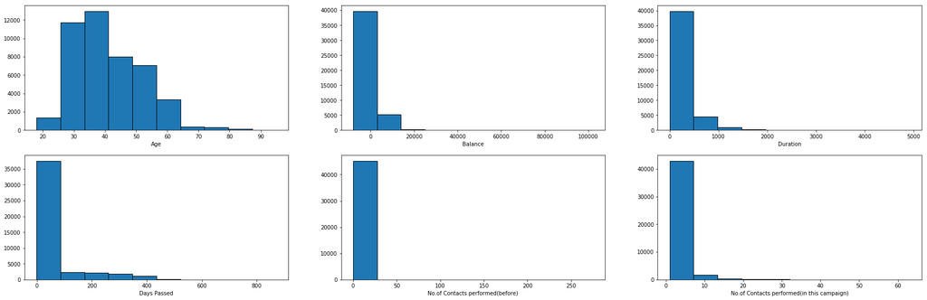

```python
plt.figure(figsize= (30,30))
plt.subplot(6,3,1)
plt.hist(bankData.age, edgecolor = 'black')
plt.xlabel('Age')

plt.subplot(6,3,2)
plt.hist(bankData.balance,edgecolor = 'black')
plt.xlabel('Balance')

plt.subplot(6,3,3)
plt.hist(bankData.duration,edgecolor = 'black')
plt.xlabel('Duration')

plt.subplot(6,3,4)
plt.hist(bankData.pdays,edgecolor = 'black')
plt.xlabel('Days Passed')

plt.subplot(6,3,5)
plt.hist(bankData.previous,edgecolor = 'black')
plt.xlabel('No.of Contacts performed(before)')

plt.subplot(6,3,6)
plt.hist(bankData.campaign,edgecolor = 'black')
plt.xlabel('No.of Contacts performed(in this campaign)')


plt.show()
```

**The distribution of all numerical variables other than age is highly skewed - hence we might want to transform them by using bins for some of these variables**

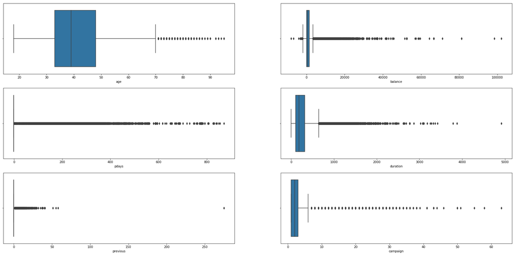

```python
plt.figure(figsize= (30,30))
plt.subplot(6,2,1)
sns.boxplot(x=bankData.age)

plt.subplot(6,2,2)
sns.boxplot(x= bankData.balance)

plt.subplot(6,2,3)
sns.boxplot(x= bankData.pdays)

plt.subplot(6,2,4)
sns.boxplot(x= bankData.duration)

plt.subplot(6,2,5)
sns.boxplot(x= bankData.previous)

plt.subplot(6,2,6)
sns.boxplot(x= bankData.campaign)

plt.show()
```

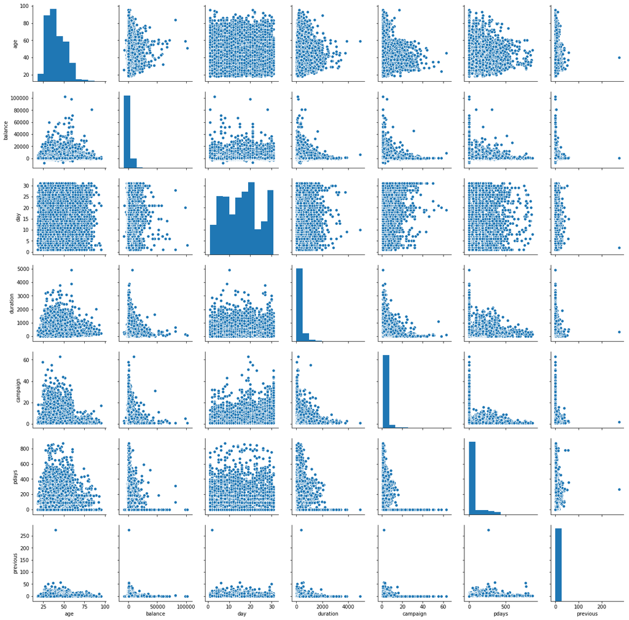

```python
# we will use the dataframe created above for Numerical attributes. (num_df)

sns.pairplot(num_df)
```

### Univariate analysis of categorical attributes.

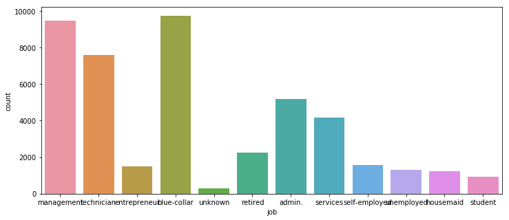

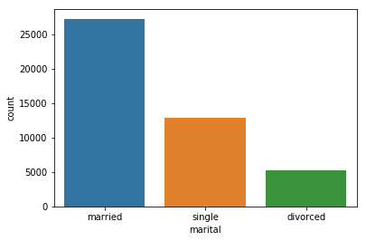

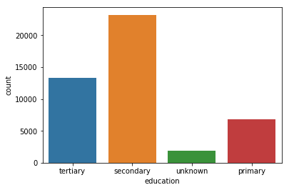

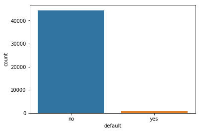

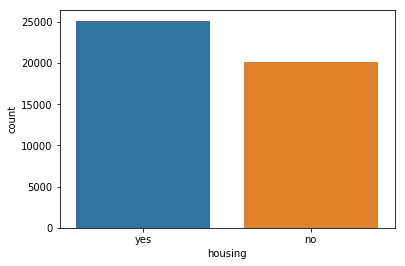

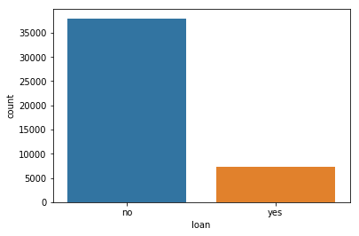

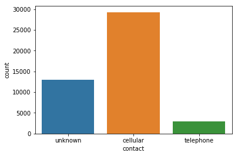

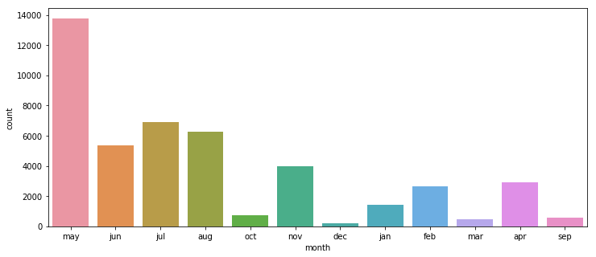

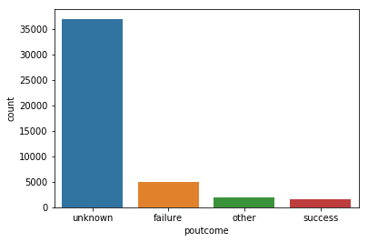

```python
catagogs = ['object']
cat_df = bankData.select_dtypes(include=catagogs)
cat_df_mod = cat_df.drop(['Target'], axis=1)

for col in cat_df_mod:
    if(col == 'job' or col == 'month'):
        plt.figure(figsize = (12,5))
        sns.countplot(cat_df_mod[col])
        plt.show()
    else:
        sns.countplot(cat_df_mod[col])
        plt.show()
```

**Default - yes has a very small percentage when compared to deafult - no.**

### Bivariate analysis of Numerical attributes.

**We check for means of all the numerical attributes for classes of target attribute.**

```python
np.round(bankData.groupby(["Target"]).mean() ,1)
```

| Target | age | balance | day | duration | campaign | pdays | previous |
| --- | --- | --- | --- | --- | --- | --- | --- |
| no | 40.8 | 1303.7 | 15.9 | 221.2 | 2.8 | 36.4 | 0.5 |
| yes | 41.7 | 1804.3 | 15.2 | 537.3 | 2.1 | 68.7 | 1.2 |

**Deductions:**

1. Mean balance for customers who subscribe is higher than those who don't.
2. Customers tend to subscribe, when duration of last call is higher.
3. If days passed since customer was last contacted is high, then there appears to be a high chance of customer subscribing.
4. Mean no.of times customer was conctated before this campaign was high for those who subscribed.

**Putting together, customers with a higher balance, those who have been contacted frequently before the campaign, those who tend to have higher call duration tend to subscribe for the term deposit**

### Bivariate analysis of categorical attributes.

```python
# we will use crosstab to give us value counts for each of the classes of target attribute.

for col in cat_df:
    if(col != 'Target'):
        print(pd.crosstab(cat_df[col], cat_df['Target'], normalize='index').sort_values(by='yes',ascending=False))
        print('\n\n')
```

```
Target               no       yes
job
student        0.713220  0.286780
retired        0.772085  0.227915
unemployed     0.844973  0.155027
management     0.862444  0.137556
admin.         0.877973  0.122027
self-employed  0.881571  0.118429
unknown        0.881944  0.118056
technician     0.889430  0.110570
services       0.911170  0.088830
housemaid      0.912097  0.087903
entrepreneur   0.917283  0.082717
blue-collar    0.927250  0.072750



Target          no       yes
marital
single    0.850508  0.149492
divorced  0.880545  0.119455
married   0.898765  0.101235



Target           no       yes
education
tertiary   0.849936  0.150064
unknown    0.864297  0.135703
secondary  0.894406  0.105594
primary    0.913735  0.086265



Target         no       yes
default
no       0.882039  0.117961
yes      0.936196  0.063804


```

[output cut: 31 more lines]

```
aug     0.889867  0.110133
jun     0.897772  0.102228
nov     0.898489  0.101511
jan     0.898788  0.101212
jul     0.909065  0.090935
may     0.932805  0.067195



Target          no       yes
poutcome
success   0.352747  0.647253
other     0.833152  0.166848
failure   0.873903  0.126097
unknown   0.908385  0.091615
```

### Deductions

1. Students tend to subscribe for term deposit more than others.
2. Customers contacted in months of Mar,dec,sep, and oct seems to have significantly higher chance of subscribing to term deposit.
3. Customers who are success in previous marketing campaigns also tend to have higher chance of subscription.
4. Rest of the attributes does not give any significant patterns or donot provide any pointers to feature selection

### Target attibute analysis.

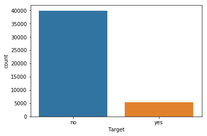

```python
sns.countplot(bankData['Target'])
```

```python
bankData['Target'].value_counts(normalize=True)
```

```
no     0.883015
yes    0.116985
Name: Target, dtype: float64
```

**As we see from above two outputs, that only 11.69% of the customers subscribe to the term deposit. Hence showing imabalance in data w.r.t to target column.**

**So any 'potential' customer for subscription if classified as 'non-potential' can have a critical effect on the bussiness.**

## 4. Prepare the data to train a model

### Categorical Attribute Treatment

**we start by encoding the categorical attributes**  
**we will use label encoder**

```python
# we start by encoding the categorical attributes
# we will use label encoder

from sklearn.preprocessing import LabelEncoder

labelencoder_X = LabelEncoder()

for col in cat_df:
    bankData[col] = labelencoder_X.fit_transform(bankData[col])
    print("values for %s :" %col, bankData[col].unique())

bankData.head()
```

```
values for job : [ 4  9  2  1 11  5  0  7  6 10  3  8]
values for marital : [1 2 0]
values for education : [2 1 3 0]
values for default : [0 1]
values for housing : [1 0]
values for loan : [0 1]
values for contact : [2 0 1]
values for month : [ 8  6  5  1 10  9  2  4  3  7  0 11]
values for poutcome : [3 0 1 2]
values for Target : [0 1]
```

|  | age | job | marital | education | default | balance | housing | loan | contact | day | month | duration | campaign | pdays | previous | poutcome | Target |
| --- | --- | --- | --- | --- | --- | --- | --- | --- | --- | --- | --- | --- | --- | --- | --- | --- | --- |
| 0 | 58 | 4 | 1 | 2 | 0 | 2143 | 1 | 0 | 2 | 5 | 8 | 261 | 1 | -1 | 0 | 3 | 0 |
| 1 | 44 | 9 | 2 | 1 | 0 | 29 | 1 | 0 | 2 | 5 | 8 | 151 | 1 | -1 | 0 | 3 | 0 |
| 2 | 33 | 2 | 1 | 1 | 0 | 2 | 1 | 1 | 2 | 5 | 8 | 76 | 1 | -1 | 0 | 3 | 0 |
| 3 | 47 | 1 | 1 | 3 | 0 | 1506 | 1 | 0 | 2 | 5 | 8 | 92 | 1 | -1 | 0 | 3 | 0 |
| 4 | 33 | 11 | 2 | 3 | 0 | 1 | 0 | 0 | 2 | 5 | 8 | 198 | 1 | -1 | 0 | 3 | 0 |

### Numerical attribute Treatment

**As part of attribute analysis, we noticed that several numerical attributes are highly skewed.**  
**Hence, we will using binning to group them into select categories**

#### 1. Age:

**We have see age min = 18 and max = 95. And Q3 = 48. And outlier in age : 487**  
**So we will create bins to accomadate these uniformly.**

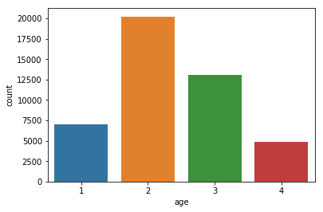

```python
# Age from 18 - 30  --> group 1
# Age from 31 - 42  --> group 2
# Age from 43 - 55  --> group 3
# Age from 56 above --> group 4


bankData.loc[(bankData['age'] <= 30) & (bankData['age'] >= 18), 'age'] = 1
bankData.loc[(bankData['age'] <= 42) & (bankData['age'] >= 31), 'age'] = 2
bankData.loc[(bankData['age'] <= 55) & (bankData['age'] >= 43), 'age'] = 3
bankData.loc[(bankData['age'] >= 56), 'age'] = 4

sns.countplot(bankData['age'])
```

#### 2. Duration

```python
print('Duration above: ', bankData['duration'].quantile(q = 0.75) +
                      1.5*(bankData['duration'].quantile(q = 0.75) - bankData['duration'].quantile(q = 0.25)), 'are outliers')
```

```
Duration above:  643.0 are outliers
```

```python
# Duration  <= 103 --> group 1
# Duration 104 - 180 --> group 2
# Duration 181 - 319 --> group 3
# Duration 320 - 643 --> group 4
# Duration 644 above --> group 5


bankData.loc[(bankData['duration'] <= 103), 'duration'] = 1
bankData.loc[(bankData['duration'] <= 180) & (bankData['duration'] >= 104), 'duration'] = 2
bankData.loc[(bankData['duration'] <= 319) & (bankData['duration'] >= 181), 'duration'] = 3
bankData.loc[(bankData['duration'] <= 643) & (bankData['duration'] >= 320), 'duration'] = 4
bankData.loc[(bankData['duration'] >= 644), 'duration'] = 5

#sns.countplot(bankData['duration'])
bankData.head()
```

|  | age | job | marital | education | default | balance | housing | loan | contact | day | month | duration | campaign | pdays | previous | poutcome | Target |
| --- | --- | --- | --- | --- | --- | --- | --- | --- | --- | --- | --- | --- | --- | --- | --- | --- | --- |
| 0 | 4 | 4 | 1 | 2 | 0 | 2143 | 1 | 0 | 2 | 5 | 8 | 3 | 1 | -1 | 0 | 3 | 0 |
| 1 | 3 | 9 | 2 | 1 | 0 | 29 | 1 | 0 | 2 | 5 | 8 | 2 | 1 | -1 | 0 | 3 | 0 |
| 2 | 2 | 2 | 1 | 1 | 0 | 2 | 1 | 1 | 2 | 5 | 8 | 1 | 1 | -1 | 0 | 3 | 0 |
| 3 | 3 | 1 | 1 | 3 | 0 | 1506 | 1 | 0 | 2 | 5 | 8 | 1 | 1 | -1 | 0 | 3 | 0 |
| 4 | 2 | 11 | 2 | 3 | 0 | 1 | 0 | 0 | 2 | 5 | 8 | 3 | 1 | -1 | 0 | 3 | 0 |

#### 3. Balance

**For balance, min = -8019.0, 25% = 72.0 , 50% = 448, 75% = 1428, max = 102127.0**

```python
bankData[(bankData['balance'] <= -1962)]

print('Balance above: ', bankData['balance'].quantile(q = 0.75) +
                      1.5*(bankData['balance'].quantile(q = 0.75) - bankData['balance'].quantile(q = 0.25)), 'are outliers')

print('Balance below: ', bankData['balance'].quantile(q = 0.25) -
                     1.5*(bankData['balance'].quantile(q = 0.75) - bankData['balance'].quantile(q = 0.25)), 'are outliers')
```

```
Balance above:  3462.0 are outliers
Balance below:  -1962.0 are outliers
```

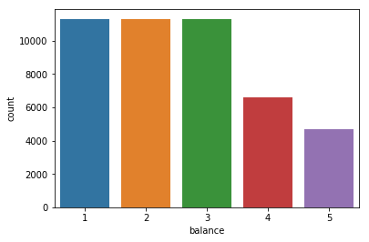

|  | age | job | marital | education | default | balance | housing | loan | contact | day | month | duration | campaign | pdays | previous | poutcome | Target |
| --- | --- | --- | --- | --- | --- | --- | --- | --- | --- | --- | --- | --- | --- | --- | --- | --- | --- |
| 0 | 4 | 4 | 1 | 2 | 0 | 4 | 1 | 0 | 2 | 5 | 8 | 3 | 1 | -1 | 0 | 3 | 0 |
| 1 | 3 | 9 | 2 | 1 | 0 | 1 | 1 | 0 | 2 | 5 | 8 | 2 | 1 | -1 | 0 | 3 | 0 |
| 2 | 2 | 2 | 1 | 1 | 0 | 1 | 1 | 1 | 2 | 5 | 8 | 1 | 1 | -1 | 0 | 3 | 0 |
| 3 | 3 | 1 | 1 | 3 | 0 | 4 | 1 | 0 | 2 | 5 | 8 | 1 | 1 | -1 | 0 | 3 | 0 |
| 4 | 2 | 11 | 2 | 3 | 0 | 1 | 0 | 0 | 2 | 5 | 8 | 3 | 1 | -1 | 0 | 3 | 0 |

```python
#balance below 72 --> group 1
#balance 73 to 448 --> group 2
#balance 449 to 1428 --> group 3
#balance 1429 to 3462 --> group 4
#balance above 3463 --> group 5


bankData.loc[(bankData['balance'] <= 72), 'balance'] = 1
bankData.loc[(bankData['balance'] <= 448) & (bankData['balance'] >= 73), 'balance'] = 2
bankData.loc[(bankData['balance'] <= 1428) & (bankData['balance'] >= 449), 'balance'] = 3
bankData.loc[(bankData['balance'] <= 3462) & (bankData['balance'] >= 1429), 'balance'] = 4
bankData.loc[(bankData['balance'] >= 3463), 'balance'] = 5

sns.countplot(bankData['balance'])
plt.show()

bankData.head()
```

## 5. Train a few standard classification algorithms, note and comment on their performances across different classification metrics.

```python
#Independant variables.
X = bankData.drop(['Target'], axis = 1)

# dependant variables
y = bankData[['Target']]

# split X and y into traning and test set in ratio of 70:30

from sklearn.model_selection import train_test_split

X_train, X_test, y_train, y_test = train_test_split(X, y, test_size=0.30, random_state=1)
```

```python
X_train.shape,  X_test.shape
```

```
((31647, 16), (13564, 16))
```

### 1. Logistic Regression

```python
from sklearn.linear_model import LogisticRegression

logmodel = LogisticRegression(solver='newton-cg')
logmodel.fit(X_train,y_train)
```

```
LogisticRegression(C=1.0, class_weight=None, dual=False, fit_intercept=True,
          intercept_scaling=1, max_iter=100, multi_class='warn',
          n_jobs=None, penalty='l2', random_state=None, solver='newton-cg',
          tol=0.0001, verbose=0, warm_start=False)
```

```python
y_predict = logmodel.predict(X_test)

model_score = logmodel.score(X_test, y_test)
print("Logistic model score:", model_score*100)

from sklearn.metrics import accuracy_score
from sklearn.metrics import recall_score
from sklearn.metrics import precision_score

acc_logi = accuracy_score(y_test,y_predict)
recall_logi = recall_score(y_test,y_predict)
pre_logi = precision_score(y_test,y_predict)

#Store the accuracy results for each model in a dataframe for final comparison
resultsDf = pd.DataFrame({'Method':['Logistic Regression'], 'accuracy': acc_logi, 'recall': recall_logi, 'precision' :pre_logi})
resultsDf = resultsDf[['Method', 'accuracy', 'recall','precision']]
resultsDf
```

```
Logistic model score: 88.7717487466824
```

|  | Method | accuracy | recall | precision |
| --- | --- | --- | --- | --- |
| 0 | Logistic Regression | 0.887717 | 0.210832 | 0.522364 |

### 2. K-NN Classifier

```python
from sklearn.neighbors import KNeighborsClassifier

#scores = {} #dictornary to capture the model score acorss each k-value
#for k in range(1,50):
#    knn_model = KNeighborsClassifier(n_neighbors = k, weights = 'distance')
#    knn_model.fit(X_train, y_train)
#    scores[k]=knn_model.score(X_test, y_test)

#best_score = max(scores.values())
#print('Best score:',best_score*100)

#best_k = max(scores, key=lambda k: scores[k])
#print('Best k-value:',best_k)

knn_model = KNeighborsClassifier(n_neighbors = 15, weights = 'distance')
knn_model.fit(X_train, y_train)
knn_predict = knn_model.predict(X_test)

acc_knn = accuracy_score(y_test,knn_predict)
recall_knn = recall_score(y_test,knn_predict, average="binary", pos_label=1)
pre_knn = precision_score(y_test,knn_predict)

tempResultsDf = pd.DataFrame({'Method':['K-NN Classifier'], 'accuracy': acc_knn, 'recall': recall_knn, 'precision' : pre_knn})
resultsDf = pd.concat([resultsDf, tempResultsDf])
resultsDf = resultsDf[['Method', 'accuracy', 'recall', 'precision']]
resultsDf
```

|  | Method | accuracy | recall | precision |
| --- | --- | --- | --- | --- |
| 0 | Logistic Regression | 0.887717 | 0.210832 | 0.522364 |
| 0 | K-NN Classifier | 0.894500 | 0.203095 | 0.617647 |

### 3. Gaussian Naive Bayes

```python
from sklearn.naive_bayes import GaussianNB # using Gaussian algorithm from Naive Bayes

# creatw the model
nb_model = GaussianNB()

#train_labels = X_train.pop('Personal Loan')
#test_labels = y_train.pop('Personal Loan')

nb_model.fit(X_train, y_train.values.ravel())
```

```
GaussianNB(priors=None, var_smoothing=1e-09)
```

```python
nb_predict = nb_model.predict(X_test)
acc_nb = accuracy_score(y_test,nb_predict)
recall_nb = recall_score(y_test,nb_predict, average="binary", pos_label=1)
pre_nb = precision_score(y_test,nb_predict, average="binary", pos_label=1)
tempResultsDf = pd.DataFrame({'Method':['Gaussian Naive Bayes'], 'accuracy': acc_nb, 'recall': recall_nb, 'precision' : pre_nb})
resultsDf = pd.concat([resultsDf, tempResultsDf])
resultsDf = resultsDf[['Method', 'accuracy', 'recall','precision']]
resultsDf
```

|  | Method | accuracy | recall | precision |
| --- | --- | --- | --- | --- |
| 0 | Logistic Regression | 0.887717 | 0.210832 | 0.522364 |
| 0 | K-NN Classifier | 0.894500 | 0.203095 | 0.617647 |
| 0 | Gaussian Naive Bayes | 0.827116 | 0.526757 | 0.336491 |

### 4. Decision Tree

```python
from sklearn.tree import DecisionTreeClassifier

model_entropy=DecisionTreeClassifier(criterion='entropy')
model_entropy.fit(X_train, y_train)
```

```
DecisionTreeClassifier(class_weight=None, criterion='entropy', max_depth=None,
            max_features=None, max_leaf_nodes=None,
            min_impurity_decrease=0.0, min_impurity_split=None,
            min_samples_leaf=1, min_samples_split=2,
            min_weight_fraction_leaf=0.0, presort=False, random_state=None,
            splitter='best')
```

```python
DT_predict = model_entropy.predict(X_test)

print("Train score : ", model_entropy.score(X_train, y_train))
print("Test Score : ", model_entropy.score(X_test , y_test))
```

```
Train score :  0.9992732328498752
Test Score :  0.8730462990268357
```

```python
model_entropy_gini=DecisionTreeClassifier()
model_entropy_gini.fit(X_train, y_train)
```

```
DecisionTreeClassifier(class_weight=None, criterion='gini', max_depth=None,
            max_features=None, max_leaf_nodes=None,
            min_impurity_decrease=0.0, min_impurity_split=None,
            min_samples_leaf=1, min_samples_split=2,
            min_weight_fraction_leaf=0.0, presort=False, random_state=None,
            splitter='best')
```

```python
model_entropy_gini.score(X_train, y_train)

gDT_predict = model_entropy_gini.predict(X_test)

print("Train score : ", model_entropy_gini.score(X_train, y_train))
print("Test Score : ", model_entropy_gini.score(X_test , y_test))
```

```
Train score :  0.9992732328498752
Test Score :  0.8680330286051312
```

**We notice a drop in model score between train and test data, which could be due to model overfitting.**  
**Hence the tree has to be pruned**

```python
clf_pruned = DecisionTreeClassifier(criterion = "entropy", random_state = 100,
                               max_depth=3, min_samples_leaf=5)
clf_pruned.fit(X_train, y_train)
```

```
DecisionTreeClassifier(class_weight=None, criterion='entropy', max_depth=3,
            max_features=None, max_leaf_nodes=None,
            min_impurity_decrease=0.0, min_impurity_split=None,
            min_samples_leaf=5, min_samples_split=2,
            min_weight_fraction_leaf=0.0, presort=False, random_state=100,
            splitter='best')
```

```python
clf_predict = clf_pruned.predict(X_test)

print("Train score : ", clf_pruned.score(X_train, y_train))
print("Test Score : ", clf_pruned.score(X_test , y_test))

acc_entro = accuracy_score(y_test,clf_predict)
recall_entro = recall_score(y_test,clf_predict, average="binary", pos_label=1)
pre_entro = precision_score(y_test,clf_predict, average="binary", pos_label=1)
tempResultsDf = pd.DataFrame({'Method':['Decision Tree (entropy)'], 'accuracy': acc_entro, 'recall': recall_entro, 'precision' : pre_entro})
resultsDf = pd.concat([resultsDf, tempResultsDf])
resultsDf = resultsDf[['Method', 'accuracy', 'recall', 'precision']]
resultsDf
```

```
Train score :  0.891616898916169
Test Score :  0.893394278973754
```

|  | Method | accuracy | recall | precision |
| --- | --- | --- | --- | --- |
| 0 | Logistic Regression | 0.887717 | 0.210832 | 0.522364 |
| 0 | K-NN Classifier | 0.894500 | 0.203095 | 0.617647 |
| 0 | Gaussian Naive Bayes | 0.827116 | 0.526757 | 0.336491 |
| 0 | Decision Tree (entropy) | 0.893394 | 0.345583 | 0.554292 |

```python
clf_pruned1 = DecisionTreeClassifier(criterion = "gini", random_state = 100,
                               max_depth=3, min_samples_leaf=5)
clf_pruned1.fit(X_train, y_train)
```

```
DecisionTreeClassifier(class_weight=None, criterion='gini', max_depth=3,
            max_features=None, max_leaf_nodes=None,
            min_impurity_decrease=0.0, min_impurity_split=None,
            min_samples_leaf=5, min_samples_split=2,
            min_weight_fraction_leaf=0.0, presort=False, random_state=100,
            splitter='best')
```

```python
clf_predict1 = clf_pruned1.predict(X_test)

print("Train score : ", clf_pruned1.score(X_train, y_train))
print("Test Score : ", clf_pruned1.score(X_test , y_test))

acc_gini = accuracy_score(y_test,clf_predict1)
recall_gini = recall_score(y_test,clf_predict1, average="binary", pos_label=1)
pre_gini = precision_score(y_test,clf_predict1, average="binary", pos_label=1)

tempResultsDf = pd.DataFrame({'Method':['Decision Tree (gini)'], 'accuracy': acc_gini, 'recall': recall_gini, 'precision': pre_gini})
resultsDf = pd.concat([resultsDf, tempResultsDf])
resultsDf = resultsDf[['Method', 'accuracy', 'recall','precision']]
resultsDf
```

```
Train score :  0.8887098303156697
Test Score :  0.8890445296372751
```

|  | Method | accuracy | recall | precision |
| --- | --- | --- | --- | --- |
| 0 | Logistic Regression | 0.887717 | 0.210832 | 0.522364 |
| 0 | K-NN Classifier | 0.894500 | 0.203095 | 0.617647 |
| 0 | Gaussian Naive Bayes | 0.827116 | 0.526757 | 0.336491 |
| 0 | Decision Tree (entropy) | 0.893394 | 0.345583 | 0.554292 |
| 0 | Decision Tree (gini) | 0.889045 | 0.223082 | 0.535604 |

#### Deductions:

- From the above table, we see that K-NN classifier has highest accuracy of 89.45%.
- However, the recall for K-NN is 0.20 which is very low. As noticed in previous sections already, the goal in this bussiness is to limit the no.of False negatives. (ie) recall_score should be close to 1.
- Keeping this in mind, we try to pick a model that gives a decent recall score when not compromising on the accuracy.

**Hence Decision Tree (entropy) is the best model from the above lot, which has an accuracy of 89.33% and a recall score of : 0.345**

## 6. Build the ensemble models and compare the results with the base models.

### 1. Random forest

```python
from sklearn.ensemble import RandomForestClassifier
rfcl = RandomForestClassifier(n_estimators = 100)
rfcl = rfcl.fit(X_train, y_train)
```

```python
pred_RF = rfcl.predict(X_test)
acc_RF = accuracy_score(y_test, pred_RF)
recall_RF = recall_score(y_test,pred_RF,average="binary", pos_label=1)
pre_RF = precision_score(y_test,pred_RF,average="binary", pos_label=1)

tempResultsDf = pd.DataFrame({'Method':['Random Forest'], 'accuracy': acc_RF, 'recall': recall_RF,'precision': pre_RF})
resultsDf = pd.concat([resultsDf, tempResultsDf])
resultsDf = resultsDf[['Method', 'accuracy', 'recall','precision']]
resultsDf
```

|  | Method | accuracy | recall | precision |
| --- | --- | --- | --- | --- |
| 0 | Logistic Regression | 0.887717 | 0.210832 | 0.522364 |
| 0 | K-NN Classifier | 0.894500 | 0.203095 | 0.617647 |
| 0 | Gaussian Naive Bayes | 0.827116 | 0.526757 | 0.336491 |
| 0 | Decision Tree (entropy) | 0.893394 | 0.345583 | 0.554292 |
| 0 | Decision Tree (gini) | 0.889045 | 0.223082 | 0.535604 |
| 0 | Random Forest | 0.904011 | 0.424242 | 0.616682 |

**Compared to the decision tree, we can see that the both accuracy and recall score has significantly improved for the Random forest model**

### 2. AdaBoosting ensemble algorithm

```python
from sklearn.ensemble import AdaBoostClassifier
abcl = AdaBoostClassifier( n_estimators= 500, learning_rate=0.1, random_state=22)
abcl = abcl.fit(X_train, y_train)
```

```python
pred_AB =abcl.predict(X_test)
acc_AB = accuracy_score(y_test, pred_AB)
recall_AB = recall_score(y_test,pred_AB,average="binary", pos_label=1)
pre_AB = precision_score(y_test,pred_AB,average="binary", pos_label=1)

tempResultsDf = pd.DataFrame({'Method':['AdaBoosting'], 'accuracy': acc_AB, 'recall': recall_AB, 'precision': pre_AB})
resultsDf = pd.concat([resultsDf, tempResultsDf])
resultsDf = resultsDf[['Method', 'accuracy', 'recall','precision']]
resultsDf
```

|  | Method | accuracy | recall | precision |
| --- | --- | --- | --- | --- |
| 0 | Logistic Regression | 0.887717 | 0.210832 | 0.522364 |
| 0 | K-NN Classifier | 0.894500 | 0.203095 | 0.617647 |
| 0 | Gaussian Naive Bayes | 0.827116 | 0.526757 | 0.336491 |
| 0 | Decision Tree (entropy) | 0.893394 | 0.345583 | 0.554292 |
| 0 | Decision Tree (gini) | 0.889045 | 0.223082 | 0.535604 |
| 0 | Random Forest | 0.904011 | 0.424242 | 0.616682 |
| 0 | AdaBoosting | 0.896491 | 0.295293 | 0.595579 |

### 3. Bagging Classifier Algorithm

```python
from sklearn.ensemble import BaggingClassifier

bgcl = BaggingClassifier(n_estimators=500, max_samples= .7, bootstrap=True, oob_score=True, random_state=22)
bgcl = bgcl.fit(X_train, y_train)
```

```python
pred_BG =bgcl.predict(X_test)
acc_BG = accuracy_score(y_test, pred_BG)
recall_BG = recall_score(y_test,pred_BG,average="binary", pos_label=1)
pre_BG = precision_score(y_test,pred_BG,average="binary", pos_label=1)

tempResultsDf = pd.DataFrame({'Method':['Bagging'], 'accuracy': acc_BG, 'recall': recall_BG,'precision': pre_BG})
resultsDf = pd.concat([resultsDf, tempResultsDf])
resultsDf = resultsDf[['Method', 'accuracy', 'recall','precision']]
resultsDf
```

|  | Method | accuracy | recall | precision |
| --- | --- | --- | --- | --- |
| 0 | Logistic Regression | 0.887717 | 0.210832 | 0.522364 |
| 0 | K-NN Classifier | 0.894500 | 0.203095 | 0.617647 |
| 0 | Gaussian Naive Bayes | 0.827116 | 0.526757 | 0.336491 |
| 0 | Decision Tree (entropy) | 0.893394 | 0.345583 | 0.554292 |
| 0 | Decision Tree (gini) | 0.889045 | 0.223082 | 0.535604 |
| 0 | Random Forest | 0.904011 | 0.424242 | 0.616682 |
| 0 | AdaBoosting | 0.896491 | 0.295293 | 0.595579 |
| 0 | Bagging | 0.903126 | 0.486138 | 0.593234 |

### 4. GradientBoost Classifier

```python
from sklearn.ensemble import GradientBoostingClassifier
gbcl = GradientBoostingClassifier(n_estimators = 500, learning_rate = 0.1, random_state=22)
gbcl = gbcl.fit(X_train, y_train)
```

```python
pred_GB =gbcl.predict(X_test)
acc_GB = accuracy_score(y_test, pred_GB)
recall_GB = recall_score(y_test,pred_GB,average="binary", pos_label=1)
pre_GB = precision_score(y_test,pred_GB,average="binary", pos_label=1)

tempResultsDf = pd.DataFrame({'Method':['Gradient Boosting'], 'accuracy': acc_GB, 'recall': recall_GB, 'precision': pre_GB})
resultsDf = pd.concat([resultsDf, tempResultsDf])
resultsDf = resultsDf[['Method', 'accuracy', 'recall','precision']]
resultsDf
```

|  | Method | accuracy | recall | precision |
| --- | --- | --- | --- | --- |
| 0 | Logistic Regression | 0.887717 | 0.210832 | 0.522364 |
| 0 | K-NN Classifier | 0.894500 | 0.203095 | 0.617647 |
| 0 | Gaussian Naive Bayes | 0.827116 | 0.526757 | 0.336491 |
| 0 | Decision Tree (entropy) | 0.893394 | 0.345583 | 0.554292 |
| 0 | Decision Tree (gini) | 0.889045 | 0.223082 | 0.535604 |
| 0 | Random Forest | 0.904011 | 0.424242 | 0.616682 |
| 0 | AdaBoosting | 0.896491 | 0.295293 | 0.595579 |
| 0 | Bagging | 0.903126 | 0.486138 | 0.593234 |
| 0 | Gradient Boosting | 0.904895 | 0.439716 | 0.618314 |

## 7. Compare performances of all the models

```python
resultsDf.sort_values(by='accuracy', ascending=False)
```

|  | Method | accuracy | recall | precision |
| --- | --- | --- | --- | --- |
| 0 | Gradient Boosting | 0.904895 | 0.439716 | 0.618314 |
| 0 | Random Forest | 0.904011 | 0.424242 | 0.616682 |
| 0 | Bagging | 0.903126 | 0.486138 | 0.593234 |
| 0 | AdaBoosting | 0.896491 | 0.295293 | 0.595579 |
| 0 | K-NN Classifier | 0.894500 | 0.203095 | 0.617647 |
| 0 | Decision Tree (entropy) | 0.893394 | 0.345583 | 0.554292 |
| 0 | Decision Tree (gini) | 0.889045 | 0.223082 | 0.535604 |
| 0 | Logistic Regression | 0.887717 | 0.210832 | 0.522364 |
| 0 | Gaussian Naive Bayes | 0.827116 | 0.526757 | 0.336491 |

**Here, we have three best models in terms of Accuracy.**

1. Randorm Forest
2. Gradient Boosting
3. Baggging.

**In order to consider which model best suits our needs, we need to identify the criticality of Type 1 and Type 2 errors.**

Type 1: False Postive : means true condition = NO SUBSCRIPTION to term deposit, but model predict = YES SUBSCRIPTION

Type 2: False Negative: means true condition = SUBSCRIPTION to term deposit, but model predict = NO SUBSCRIPTION

**In our scenarion, type 2 FN, plays a critical role, as model predicts client will NOT SUBSCRIBE, but in real world the client DID SUBSCRIBE. Because of which we may lose the customer.**

**type 1, FP, is okay because, model predicts client will SUBSCRIBE, but the real world he didnot SUBSCRIBE**

So we find out the models which has least no.of FN from the above three models.

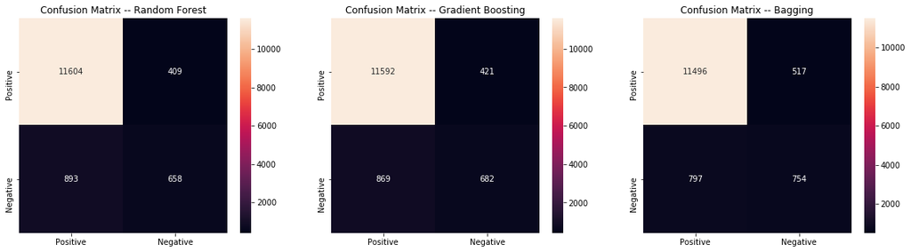

```python
from sklearn.metrics import confusion_matrix

plt.figure(figsize=(20,5))
class_label = ["Positive", "Negative"]
plt.xlabel("Predicted Label")
plt.ylabel("True Label")


plt.subplot(1,3,1)
RF_cm = confusion_matrix(y_test, pred_RF)
df_cm = pd.DataFrame(RF_cm, index = class_label, columns = class_label)
sns.heatmap(df_cm, annot = True, fmt='d')
plt.title("Confusion Matrix -- Random Forest")

plt.subplot(1,3,2)
GB_cm = confusion_matrix(y_test,pred_GB)
df_cm1 = pd.DataFrame(GB_cm, index = class_label, columns = class_label)
sns.heatmap(df_cm1, annot = True, fmt = "d")
plt.title("Confusion Matrix -- Gradient Boosting")

plt.subplot(1,3,3)
BG_cm=metrics.confusion_matrix(y_test, pred_BG)
df_cm2 = pd.DataFrame(BG_cm, index = class_label, columns = class_label)
sns.heatmap(df_cm2, annot = True, fmt = "d")
plt.title("Confusion Matrix -- Bagging")
plt.show()
```

**As we see from the above confusion matrix, Bagging has least no.of FN with 797**.

Although it can be improved to reduce the no.of FN, since it perform best among all the other models, we choose bagging a best model

### Bagging is choosen a best fit model for this case.

- **accuracy : 90.31%**
- **Recall : 0.49**
- **Precision: 0.59**